# Análisis Exploratorio del Dataset Iris

**Objetivo:** Analizar y visualizar las características de 3 especies de flores Iris. **Dataset:** Iris dataset de scikit-learn (150 muestras, 4 características)

**Autor:** Alvin Portillo **Fecha:** 2026-01-01

```python
# Importar librerias
import pandas as pd
import numpy as np
import matplotlib.pyplot as plt
import seaborn as sns
from sklearn.datasets import load_iris

# Configuración de visualización
plt.style.use('seaborn-v0_8-darkgrid')
sns.set_palette("husl")
%matplotlib inline
```

```python
# Carga de datos
iris = load_iris()

# Crear DataFrame
df = pd.DataFrame(
    data= iris.data,
    columns=iris.feature_names
)

# Agregar columna de especies
df['species'] = iris.target
df['species_name'] = df['species'].map({
    0: 'setosa',
    1: 'versicolor',
    2: 'virginica'
})
print(f"Dataset cargado: {df.shape[0]} filas, {df.shape[1]} columnas")
print(f"\nPrimeras 5 filas")
df.head(5)
```

```
Dataset cargado: 150 filas, 6 columnas

Primeras 5 filas
```

|  | sepal length (cm) | sepal width (cm) | petal length (cm) | petal width (cm) | species | species_name |
| --- | --- | --- | --- | --- | --- | --- |
| 0 | 5.1 | 3.5 | 1.4 | 0.2 | 0 | setosa |
| 1 | 4.9 | 3.0 | 1.4 | 0.2 | 0 | setosa |
| 2 | 4.7 | 3.2 | 1.3 | 0.2 | 0 | setosa |
| 3 | 4.6 | 3.1 | 1.5 | 0.2 | 0 | setosa |
| 4 | 5.0 | 3.6 | 1.4 | 0.2 | 0 | setosa |

## 1. Exploración inicial

El dataset Iris contiene mediciones de 150 flores de 3 especies diferentes:

- **Setosa**
- **Versicolor**
- **Virginica**

Cada flor tiene 4 mediciones (en cm):

- Longitud de sépalo
- Ancho del sépalo
- Longitud del pétalo
- Ancho del pétalo

```python
# Información general
print("INFORMACIÓN DEL DATASET")
print(df.info())

print("ESTADISTICAS DESCRIPTTIVAS")
print(df.describe())

print("DISTRIBUCIÓN DE ESPECIES")
print(df['species_name'].value_counts())
```

```
INFORMACIÓN DEL DATASET
<class 'pandas.core.frame.DataFrame'>
RangeIndex: 150 entries, 0 to 149
Data columns (total 6 columns):
 #   Column             Non-Null Count  Dtype
---  ------             --------------  -----
 0   sepal length (cm)  150 non-null    float64
 1   sepal width (cm)   150 non-null    float64
 2   petal length (cm)  150 non-null    float64
 3   petal width (cm)   150 non-null    float64
 4   species            150 non-null    int64
 5   species_name       150 non-null    object
dtypes: float64(4), int64(1), object(1)
memory usage: 7.2+ KB
None
ESTADISTICAS DESCRIPTTIVAS
       sepal length (cm)  sepal width (cm)  petal length (cm)  \
count         150.000000        150.000000         150.000000
mean            5.843333          3.057333           3.758000
std             0.828066          0.435866           1.765298
min             4.300000          2.000000           1.000000
25%             5.100000          2.800000           1.600000
50%             5.800000          3.000000           4.350000
75%             6.400000          3.300000           5.100000
max             7.900000          4.400000           6.900000

       petal width (cm)     species
count        150.000000  150.000000
mean           1.199333    1.000000
std            0.762238    0.819232
min            0.100000    0.000000
25%            0.300000    0.000000
50%            1.300000    1.000000
75%            1.800000    2.000000
max            2.500000    2.000000
DISTRIBUCIÓN DE ESPECIES
species_name
setosa        50
versicolor    50
virginica     50
Name: count, dtype: int64
```

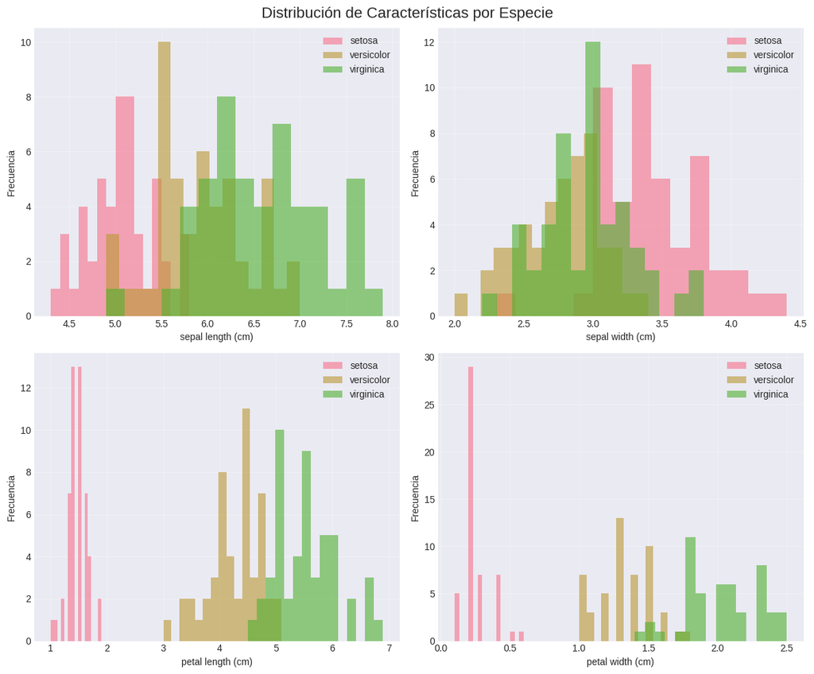

```python
# Histogramas de las 4 características
fig, axes = plt.subplots(2,2,figsize=(12,10))
fig.suptitle('Distribución de Características por Especie',fontsize=16)

features = iris.feature_names

for idx, feature in enumerate(features):
    ax = axes[idx//2,idx%2]

    for species in df['species_name'].unique():
        data = df[df['species_name']==species][feature]
        ax.hist(data, alpha=0.6, label=species, bins=15)

    ax.set_xlabel(feature, fontsize=10)
    ax.set_ylabel('Frecuencia', fontsize=10)
    ax.legend()
    ax.grid(True, alpha=0.3)

plt.tight_layout()
plt.show()
```

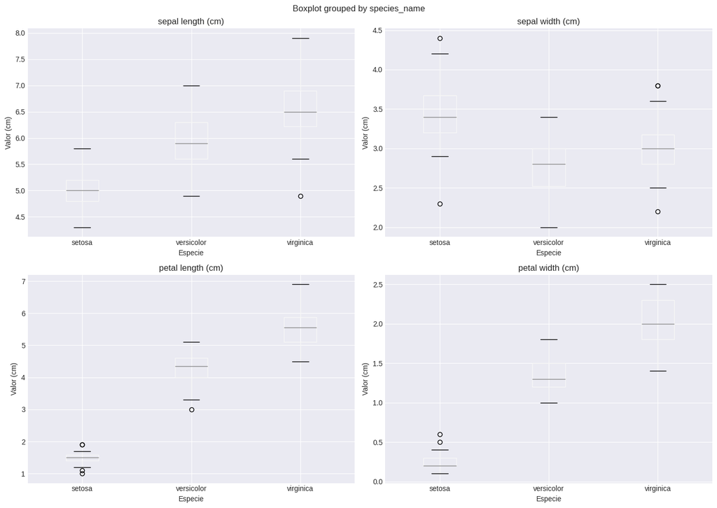

```python
# Boxplot para comparar especies
fig, axes = plt.subplots(2,2, figsize=(14,10))
fig.suptitle('Comparación de caraterísticas entre especies', fontsize = 16)

for idx, feature in enumerate(features):
    ax = axes[idx//2, idx%2]

    df.boxplot(column=feature, by='species_name',ax=ax)
    ax.set_title(feature)
    ax.set_xlabel('Especie')
    ax.set_ylabel('Valor (cm)')

plt.tight_layout()
plt.show()
```

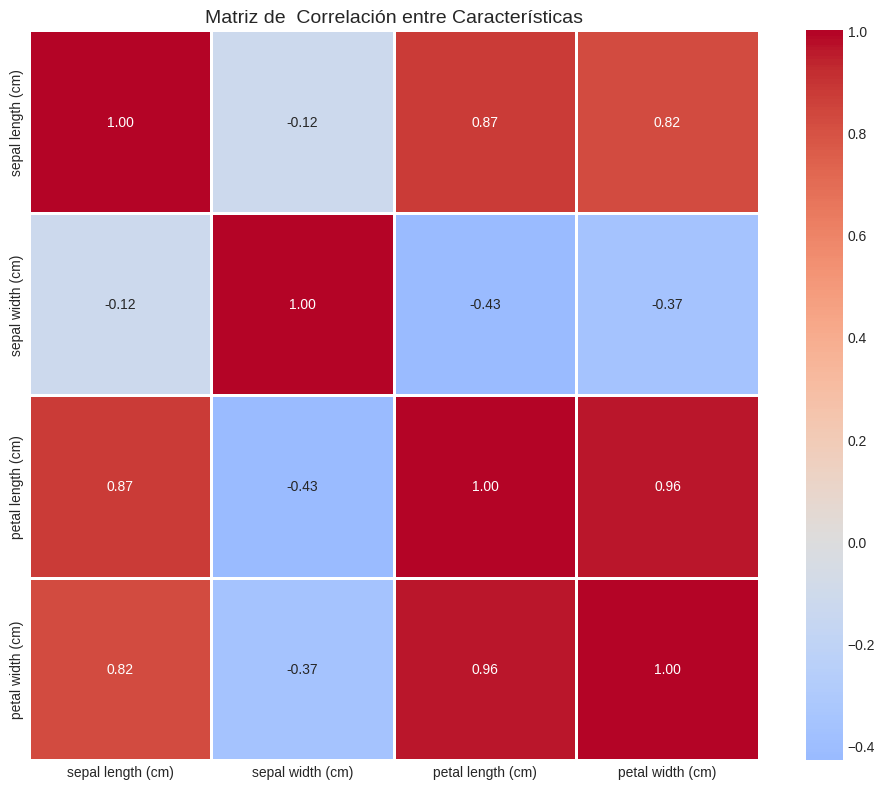

```python
# Mapa de calor de correlaciones
plt.figure(figsize=(10,8))

correlacion = df[features].corr()
sns.heatmap(
    correlacion,
    annot=True,
    fmt='.2f',
    cmap='coolwarm',
    center=0,
    square=True,
    linewidths=1
)

plt.title('Matriz de  Correlación entre Características', fontsize =14)
plt.tight_layout()
plt.show()
```

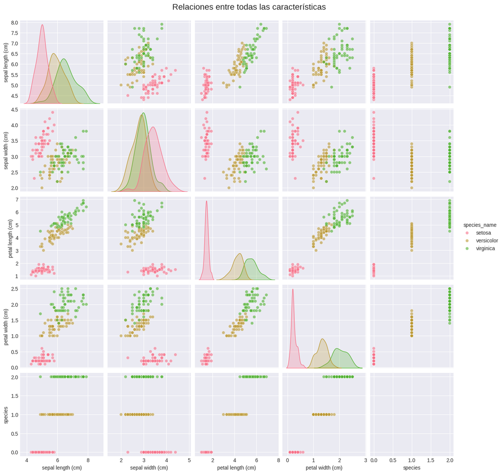

```python
# PairPlot -  Visualización de todas las relaciones
plt.figure(figsize=(20,10))

pairplot = sns.pairplot(
    df,
    hue='species_name',
    height=2.5,
    diag_kind='kde',
    plot_kws={'alpha': 0.6}
)

pairplot.fig.suptitle('Relaciones entre todas las características',
                      y=1.02, fontsize=16)

plt.show()
```

### Observaciones:

1. **Separabilidad de especies:**
   - La especie **Setosa** es claramente disinguible de las otras dos
   - *Versicolor* y *Virginica* tienen cierta superposición
2. **Características más distintivas:**
   - Longitud y ancho del pétalo son los mejores discriminadores
   - Setosa tiene pétalos significativamente más pequeños
3. **Correlaciones:**
   - Fuerte correlación positiva entre lontitud de pétalo y longitud de sépalo (0.87)
   - Fuerte correlación entre longitud y ancho del pétalo (0.96)
4. **Distribuciones:**
   - Todas las características siguen distribuciones aproximádamente normales
   - Algunas especies muestran bimodalidad en ciertas características

## Aplicaciones potenciales:

Este análisis demuestra que con sólo 4 medidas simples podríamos construir un modelo de Machine Learning para clasificar especies de Iris con alta precisión.

```python
# Preparación básica para un modelo de clasificación
from sklearn.model_selection import train_test_split
from sklearn.preprocessing import StandardScaler

# Separar features y target
X = df[features]
y = df['species']

# Split train/test
X_train, X_test, y_train, y_test = train_test_split(
    X, y, test_size=0.2, random_state=42, stratify=y
)

# Escalar datos
scaler = StandardScaler()
X_train_scaled = scaler.fit_transform(X_train)
X_test_scaled = scaler.transform(X_test)

print("Datos preparados para Machine Learning")
print(f"\nTrain set: {X_train.shape[0]} muestras")
print(f"Test set: {X_test.shape[0]} muestras")
print(f"\nDistribución en train set:")
print(pd.Series(y_train).value_counts())
```

```
Datos preparados para Machine Learning

Train set: 120 muestras
Test set: 30 muestras

Distribución en train set:
species
0    40
2    40
1    40
Name: count, dtype: int64
```

## 3. Conclusiones

Este análisis exploratorio del dataset Iris demuestra:

- Capacidad de cargar y manipular datos con Pandas
- Creación de visualizaciones profesionales con Matplotlib/Seaborn
- Análisis estadístico e identificación de patrones
- Preparación de datos para Machine Learning

**Próximo pasos sugeridos:**

1. Implementar modelo de clasificación (KNN, Decision Tree, SVM)
2. Evaluar precisión del modelo
3. Comparar diferentes algoritmos
4. Deployment como API o app web

**Dataset:** Fisher's Iris Dataset (1936) **Herramientas:** Python, Pandas, Matplotlib, Seaborn, Scikit-learn